# Homework_3

**Group E: Tasciotti, Arrighi, Castelli, Carraro**

```r
library(bayesplot)
library(boot)
#library(DAAG)
library(ggplot2)
library(MASS)
library(rstan)
library(rstanarm)
library(LearnBayes)
```

## LEC Exercises

### Exercise 1

**Compute the bootstrap-based confidence interval for the `score` dataset using the studentized method.**

#### Solution

The `score` dataset used in this exercise was taken from here https://web.stanford.edu/~hastie/CASI/data.html.

```r
score <- read.table("student_score.txt",header = TRUE)
print(cor(score))
```

```
##            mech      vecs       alg     analy      stat
## mech  1.0000000 0.4978075 0.7560364 0.6534763 0.5357744
## vecs  0.4978075 1.0000000 0.5922624 0.5071353 0.3786038
## alg   0.7560364 0.5922624 1.0000000 0.7627546 0.6698255
## analy 0.6534763 0.5071353 0.7627546 1.0000000 0.7376712
## stat  0.5357744 0.3786038 0.6698255 0.7376712 1.0000000
```

The parameter of interest is the $\mathsf{eigenratio}$ statistic for the above correlation matrix. Let $\lambda_i$ be the $i$-th eigenvalue of the correlation matrix. Then the $\mathsf{eigenratio}$ statistic is given by $\hat\psi= \frac{\lambda_{max}}{\sum_i \lambda_i}$. The studentized method requires a standard error estimate $SE(\hat{\psi}^{*})$ from each bootstrap sample and since explicit estimates of $SE(\hat{\psi}^{*})$ would be very hard, we employ the $\mathsf{jackknife}$ within each bootstrap sample.
Denoting by $z_{0.025}^*$ and $z_{0.975}^*$ the bootstrap quantiles of $z^{*1}, \ldots, z^{*B}$, where $z^{*b}=\frac{\hat\psi^{*b}-\hat\psi}{SE(\hat\psi^{*b})}$, the studentized bootstrap confidence interval is given by
$$\bigg(\hat\psi-SE(\hat\psi)z_{0.975}^*,\hat\psi-SE(\hat\psi)z_{0.025}^*\bigg).$$

```r
# compute the eigenratio statistic
eigenratio <- function(y) {
  lambda <- eigen(cor(y))$values
  return(max(lambda) / sum(lambda))
}

# psi hat
psi_obs <- eigenratio(score)

# Compute confidence intervals
set.seed(123)
n <- nrow(score)
B <- 10^4
s_stat <- rep(0,n)
s_vect <- rep(0, B)
SE_jack <- rep(0, B)

for(i in 1:B){
  ind <- sample(1:n, n, replace = TRUE)
  s_vect[i] <- eigenratio(score[ind,])

  # Sample without j-th obs
  for(j in 1:n) s_stat[j] <- eigenratio(score[ind,][-j,])

  # Jackknife estimate of the standard error
  SE_jack[i] <- sqrt(((n - 1)/n) * sum((s_stat - mean(s_stat))^2))
}

SE_boot <- sd(s_vect)

# studentized confidence intervals
z<-(s_vect - psi_obs)/SE_jack
studentized_ci <- psi_obs - quantile(z, prob=c(0.975, 0.025))*SE_boot
studentized_ci
```

```
##     97.5%      2.5%
## 0.5091440 0.8580867
```

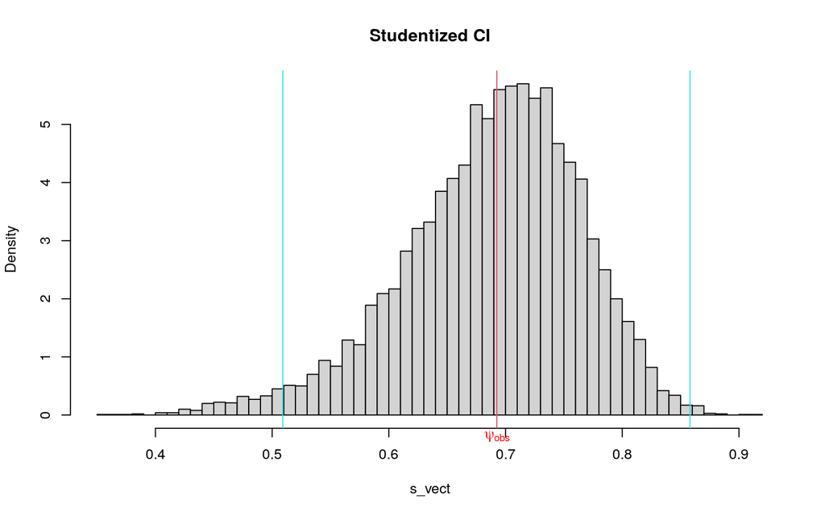

```r
hist.scott(s_vect, main = "Studentized CI")
abline(v = psi_obs, col = 2)
mtext(expression(psi[obs]), 1, at=psi_obs, col="red")
abline(v=studentized_ci[1],col = 5)
abline(v=studentized_ci[2],col = 5)
```

### Exercise 2

**Compute bootstrap-based confidence intervals for the `score` dataset using the `boot` package.**

#### Solution

```r
set.seed(123)
n <- nrow(score)
B <- 10^4
s_stat <- rep(0, n)
SE_jack <- rep(0, B)

statistic_boot <-function(y, ind) {
  y <- y[ind,]
  s_vect=eigenratio(y)

  # jackknife standard error estimate
  for (j in 1:n) s_stat[j] <- eigenratio(y[-j,])
  SE_jack[ind] <- ((n - 1)/n) * sum((s_stat - mean(s_stat))^2)

  return(c(s_vect, SE_jack))
}

# bootstrap resampling
score.boot <- boot(data = score, statistic = statistic_boot, R = B)
# compute confidence intervals
boot.ci(score.boot,type = "stud")
```

```
## BOOTSTRAP CONFIDENCE INTERVAL CALCULATIONS
## Based on 10000 bootstrap replicates
##
## CALL :
## boot.ci(boot.out = score.boot, type = "stud")
##
## Intervals :
## Level    Studentized
## 95%   ( 0.4950,  0.8516 )
## Calculations and Intervals on Original Scale
```

From these results we can see that the confidence intervals computed with the `boot.ci` function are slightly different from those calculated “by hand” in Exercise 1. This is probably due to some different method used by `boot.ci`.

## LAB Exercises

Exercises 1, 2, 3, 5, 6, 7, 8, 9, 10 (from Lab 3).

### Exercise 1

**Use `nlm` to compute the variance for the estimator $\hat{w}=(log(\hat\gamma),log(\hat\beta))$ and `optimHess` for the variance of $\hat\theta=(\hat\gamma, \hat\beta)$.**

#### Solution

```r
# data
y <- c(155.9, 200.2, 143.8, 150.1,152.1, 142.2, 147, 146, 146,
 170.3, 148, 140, 118, 144, 97)

# log-likelihood function
log_lik_weibull <- function(data, param){
  -sum(dweibull(data, shape = param[1], scale = param[2], log = TRUE))
}

# reparametrization
omega <- function(theta) log(theta)
theta <- function(omega) exp(omega)
log_lik_weibull_rep <- function(data, param) log_lik_weibull(data, theta(param))

# numerical optimization with nlm
weib.y.nlm<-nlm(log_lik_weibull_rep, c(0,0), hessian=T, data=y)
weib.y.nlm
```

```
## $minimum
## [1] 68.1784
##
## $estimate
## [1] 1.929516 5.049524
##
## $gradient
## [1] -6.724230e-06  2.123386e-05
##
## $hessian
##           [,1]      [,2]
## [1,]  34.53496 -51.49153
## [2,] -51.49153 708.83544
##
## $code
## [1] 2
##
## $iterations
## [1] 30
```

The output `hessian` returned by the `nlm` function is the Fisher Information Matrix $I(\hat{w})$ evaluated at $(log(\hat\gamma),log(\hat\beta))$. The inverse of $I(\hat{w})$ is the variance-covariance matrix $C(\hat{w})$ and the variance for the estimator $\hat{w}=(log(\hat\gamma),log(\hat\beta))$ can be computed as
$$var(\hat{w_i})=C_{ii}(\hat{w}),$$
where $C_{ii}(\hat{w})$ is the $i$-th diagonal element of the variance-covariance matrix. Thus, we use the function `solve` to compute the inverse of $I(\hat{w})$ and then we apply `diag` to get the diagonal elements of the variance-covariance matrix.

```r
# diagonal elements of the inverse fisher information matrix
diag(solve(weib.y.nlm$hessian))
```

```
## [1] 0.032473346 0.001582124
```

Thus, the variance for the estimator $\hat{w}=(\log(\hat\gamma),\log(\hat\beta))$ is $(0.032473346,0.001582124)$.

In order to compute the variance of $\hat\theta=(\hat\gamma,\hat\beta)$, we re-express the parameters in the original scale and we pass them to the `optimHess` function which computes the hessian evaluated at $(\hat \gamma, \hat \beta)$. Then, we invert the hessian and we take the diagonal elements of the obtained matrix.

```r
# compute the hessian with optimHess
hessian_theta<-optimHess(theta(weib.y.nlm$estimate),log_lik_weibull,data=y)

# diagonal elements of the inverse fisher information matrix
diag(solve(hessian_theta))
```

```
## [1]  1.543241 38.406119
```

The variance of $\hat\theta=(\hat\gamma,\hat\beta)$ is $(1.543241,38.406118)$.

### Exercise 2

The Wald confidence interval with level $1-\alpha$ is defined as:
$$\hat{\gamma} \,\pm\,z_{1-\alpha} j_P(\hat{\gamma})^{-\frac{1}{2}}.$$
Compute the Wald confidence interval of level $0.95$ and plot the results.

#### Solution

```r
# data
y <- c(155.9, 200.2, 143.8, 150.1,152.1, 142.2, 147, 146, 146,
       170.3, 148, 140, 118, 144, 97)


# functions
log_lik_weibull <- function( data, param){
    -sum(dweibull(data, shape = param[1], scale = param[2], log = TRUE))
}

log_lik_weibull_profile <- function(data, gamma){
    beta.gamma <- mean(data^gamma)^(1/gamma)
    log_lik_weibull( data, c(gamma, beta.gamma) )
}

log_lik_weibull_profile_v <- Vectorize(log_lik_weibull_profile, 'gamma')


# compute MLE with an optimization method
weib.y.mle<-optim(1,fn=log_lik_weibull_profile,hessian=T,
                  method='L-BFGS-B',lower=rep(1e-7,2),
                  upper=rep(Inf,2),data=y)
weib.y.mle
```

```
## $par
## [1] 6.886215
##
## $value
## [1] 68.1784
##
## $counts
## function gradient
##        9        9
##
## $convergence
## [1] 0
##
## $message
## [1] "CONVERGENCE: REL_REDUCTION_OF_F <= FACTR*EPSMCH"
##
## $hessian
##           [,1]
## [1,] 0.6479831
```

```r
# compute standard error
se<-sqrt(diag(solve(weib.y.mle$hessian)))
se
```

```
## [1] 1.242276
```

```r
# compute bounds of confidence interval with level 0.95
conf_level<-0.95
wald.ci<-weib.y.mle$par[1]+c(-1,1)*qnorm(1-(1-conf_level)/2)*se[1]
wald.ci
```

```
## [1] 4.451398 9.321031
```

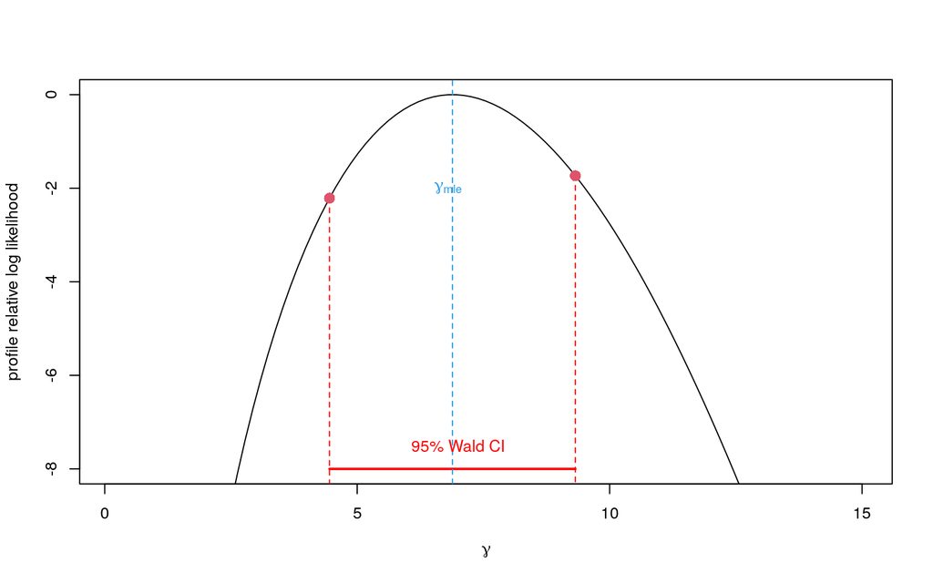

```r
# plot
plot(function(x) -log_lik_weibull_profile_v(data=y, x)+weib.y.mle$value,
     from=0.1,to=15,xlab=expression(gamma),
     ylab='profile relative log likelihood',ylim=c(-8,0))

segments(wald.ci[1], -log_lik_weibull_profile_v(y,wald.ci[1])+weib.y.mle$value,
         wald.ci[1], -log_lik_weibull_profile_v(y, wald.ci[1]),
         col="red", lty=2)
segments(wald.ci[2], -log_lik_weibull_profile_v(y,wald.ci[2])+weib.y.mle$value,
         wald.ci[2], -log_lik_weibull_profile_v(y, wald.ci[2]),
         col="red", lty=2 )
points(wald.ci[1],-log_lik_weibull_profile_v(y,wald.ci[1])+weib.y.mle$value, pch=16, col=2, cex=1.5)
points(wald.ci[2],-log_lik_weibull_profile_v(y,wald.ci[2])+weib.y.mle$value, pch=16, col=2, cex=1.5)
segments(wald.ci[1], -8,  wald.ci[2], -8, col="red", lty =1, lwd=2)
abline(v=weib.y.mle$par[1], col=4, lwd=1, lty=2)
text(6.8, -2, expression(gamma[mle]), col=4)
text(7,-7.5,"95% Wald CI",col="red")
```

### Exercise 3

**Repeat the steps above - write the profile log-likelihood, plot it and find the deviance confidence intervals - considering this time $\gamma$ as a nuisance parameter and $\beta$ as the parameter of interest.**

#### Solution

```r
# data
y <- c(155.9, 200.2, 143.8, 150.1,152.1, 142.2, 147, 146, 146, 170.3, 148, 140, 118, 144, 97)
n <- length(y)

beta <- seq(100,200, length=100)


# functions
log_lik_weibull <- function( data, param) {
    -sum(dweibull(data, shape = param[1], scale = param[2], log = TRUE))
}

log_lik_weibull_profile <- function(data, beta) {
    gamma.beta <- uniroot(function(x) n/x - n * log(beta) + sum(log(data)) - sum((data/beta)^x *
            log(data/beta)), c(1e-5,15))$root
    log_lik_weibull(data, c(gamma.beta, beta))
}
log_lik_weibull_profile_v <- Vectorize(log_lik_weibull_profile, 'beta')

# compute MLE with an optimization method
weib.y.mle<-optim(c(1,1),fn=log_lik_weibull,hessian=T, method='L-BFGS-B',lower=rep(1e-7,2),
                  upper=rep(Inf,2), data=y)
weib.y.mle
```

```
## $par
## [1]   6.886216 155.948671
##
## $value
## [1] 68.1784
##
## $counts
## function gradient
##       30       30
##
## $convergence
## [1] 0
##
## $message
## [1] "CONVERGENCE: REL_REDUCTION_OF_F <= FACTR*EPSMCH"
##
## $hessian
##             [,1]        [,2]
## [1,]  0.72786861 -0.04833691
## [2,] -0.04833691  0.02924752
```

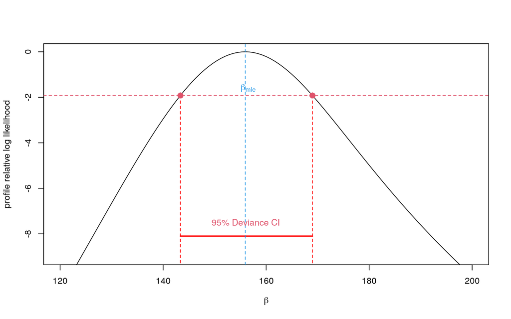

```r
# plot
plot(function(x) -log_lik_weibull_profile_v(data=y, x) + weib.y.mle$value, from=120, to=200,
     xlab=expression(beta), ylab='profile relative log likelihood', ylim=c(-9,0))

conf.level<-0.95
abline(h=-qchisq(conf.level,1)/2,lty='dashed',col=2)

lrt.ci1<-uniroot(function(x) -log_lik_weibull_profile_v(y, x)+
                   weib.y.mle$value+qchisq(conf.level,1)/2, c(1e-7,weib.y.mle$par[2]))$root

lrt.ci1<-c(lrt.ci1,uniroot(function(x) -log_lik_weibull_profile_v(y,x)+weib.y.mle$value+
                               qchisq(conf.level,1)/2, c(weib.y.mle$par[2],200))$root)

segments( lrt.ci1[1],-qchisq(conf.level,1)/2, lrt.ci1[1],
          -log_lik_weibull_profile_v(y, lrt.ci1[1]), col="red", lty=2)

segments( lrt.ci1[2],-qchisq(conf.level,1)/2, lrt.ci1[2],
          -log_lik_weibull_profile_v(y, lrt.ci1[2]), col="red", lty=2)

points(lrt.ci1[1], -qchisq(0.95,1)/2, pch=16, col=2, cex=1.5)
points(lrt.ci1[2], -qchisq(0.95,1)/2, pch=16, col=2, cex=1.5)
segments( lrt.ci1[1], -8.1, lrt.ci1[2], -8.1, col="red", lty =1, lwd=2)
abline(v=weib.y.mle$par[2], col=4, lwd=1, lty=2)
text(156.5, -1.6, expression(beta[mle]), col=4)
text(156,-7.5,"95% Deviance CI",col=2)
```

### Exercise 5

**In `sim` in the code above, you find the MCMC output which allows to approximate the posterior distribution of our parameter of interest with $S$ draws of $\theta$. Please, produce an histogram for these random draws $\theta(1), \ldots, \theta(S)$, compute the empirical quantiles, and overlap the true posterior distribution.**

#### Solution

```r
## input variables:
# true mean
theta_sample <- 2
# likelihood variance
sigma2 <- 2
# sample size
n <- 10
# prior mean
mu <- 7
# prior variance
tau2 <- 2

# generate some data
set.seed(123)
y <- rnorm(n,theta_sample, sqrt(sigma2))

# posterior mean
mu_star <- ((1/tau2)*mu+(n/sigma2)*mean(y))/( (1/tau2)+(n/sigma2))
# posterior standard deviation
sd_star <- sqrt(1/( (1/tau2)+(n/sigma2)))


# launch Stan model
data<- list(N=n, y=y, sigma =sqrt(sigma2), mu = mu, tau = sqrt(tau2))
fit <- stan(file="normal.stan", data = data, chains = 4, iter=2000)
```

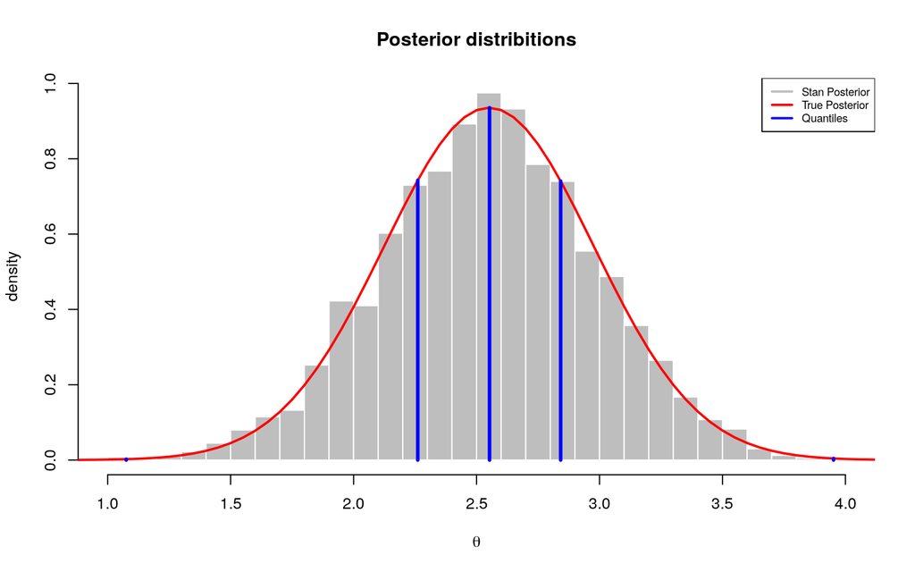

```r
# extract the posterior draws
sim = extract(fit)
theta_draws = sim$theta  # 1000 draws for each chain
# head(theta_draws)

hist(theta_draws, breaks= 40, probability = TRUE, xlab=expression(theta), ylab="density",
     main = "Posterior distribitions", col = "grey",  border="white")
curve(dnorm(x, mu_star, sd_star), xlab=expression(theta), ylab="", col="red", lwd=2,
      add=T, xlim=c(0,5))

# empirical quantiles
quant <- quantile(theta_draws)
segments(quant, 0, quant, dnorm(quant, mu_star, sd_star), col="blue", lwd=3)

legend("topright", c("Stan Posterior", "True Posterior","Quantiles"),
  col=c("grey", "red", "blue" ), lty=c(1,1,1), lwd = c(2,2,2), cex=0.7)
```

### Exercise 6

**Launch the following line of $\mathsf{R}$ code:**

`posterior <- as.array(fit)`

**Use now the `bayesplot` package. Read the help and produce for this example, using the object posterior, the following plots:**

- **posterior intervals.**
- **posterior areas.**
- **marginal posterior distributions for the parameters.**

**Quickly comment.**

#### Solution

```r
# returns an array of theta draws
posterior <- as.array(fit)
print(dimnames(posterior))
```

```
## $iterations
## NULL
##
## $chains
## [1] "chain:1" "chain:2" "chain:3" "chain:4"
##
## $parameters
## [1] "theta" "lp__"
```

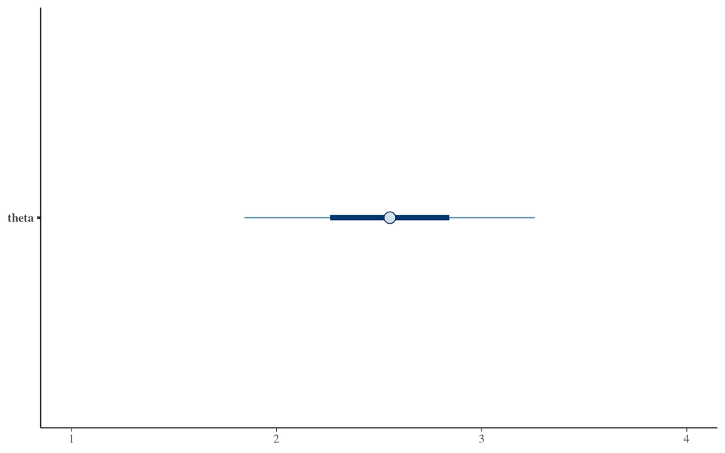

```r
color_scheme_set("blue")
mcmc_intervals(posterior, pars = "theta") + xlim(1, 4)
```

```r
mcmc_intervals_data(posterior, pars = "theta")
```

```
## # A tibble: 1 x 9
##   parameter outer_width inner_width point_est    ll     l     m     h    hh
##   <fct>           <dbl>       <dbl> <chr>     <dbl> <dbl> <dbl> <dbl> <dbl>
## 1 theta             0.9         0.5 median     1.84  2.26  2.55  2.84  3.26
```

In this plot are shown the central posterior uncertainty intervals of the parameter $\theta$ computed from MCMC draws, based on quantiles. By default the central point is the posterior median. The thick segments represents the $50\%$ intervals and the thinner outer lines the $90\%$ intervals. In our case $90\%$ credible interval means that the subjective probability that the true $\theta$ is somewhere between $[1.84, 3.26]$ is $90\%$.

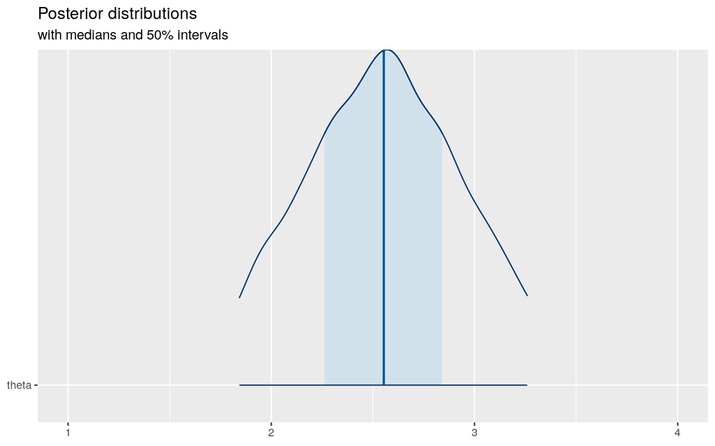

```r
color_scheme_set("blue")
plot_title <- ggtitle("Posterior distributions", "with medians and 80% intervals")
mcmc_areas(
  posterior,
  pars = c("theta"),
  prob = 0.5, # 50% intervals
  prob_outer = 0.90, # 90% intervals
  point_est = "median"
) + theme_gray() + ggtitle("Posterior distributions", "with medians and 50% intervals") +
  xlim(1, 4)
```

This plot shows the uncertainty intervals of $\theta$ draws from the posterior as shaded areas under the estimated posterior density curve. In this case the shaded area represents the $50\%$ credible interval, as in the plot before the probability of $\theta$ to be in $[2.26, 2.84]$ is $50\%$. The central line is the estimate of the posterior median.

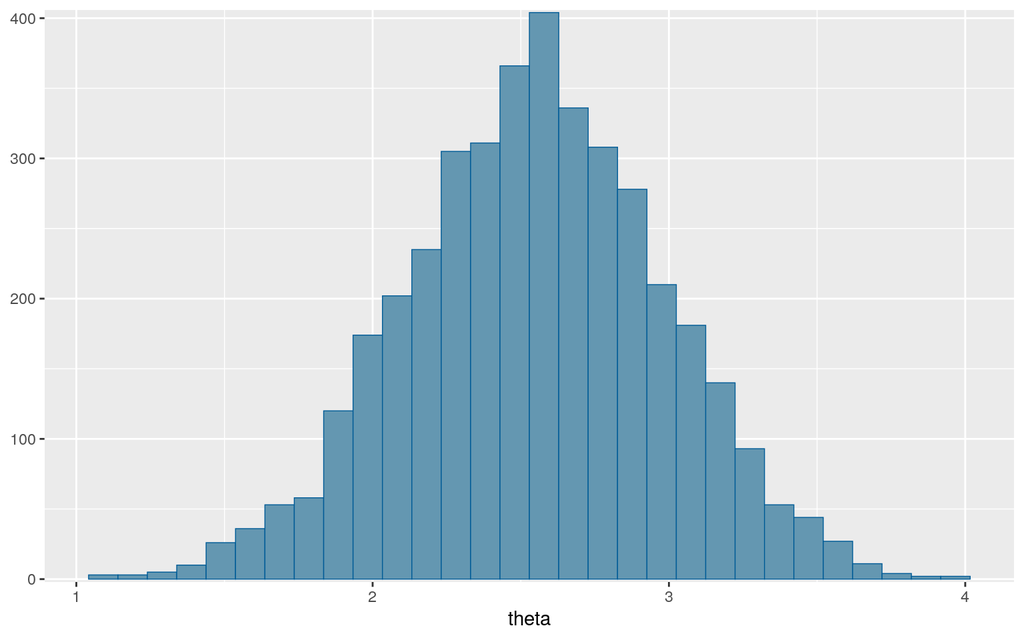

```r
color_scheme_set("blue")
mcmc_hist(posterior, pars = "theta") + theme_gray()
```

This plot combines all chains and depicts the marginal posterior distrubutions of the parameter $\theta$. The histogram represents the different draws of $\theta$ from the posterior.

### Exercise 7

**Suppose you receive $n=15$ phone calls in a day, and you want to build a model to assess their average length. Your likelihood for each call length is $y_i \sim Poisson(\lambda)$. Now, you have to choose the prior $\pi(\lambda)$. Please, tell which of these priors is adequate to describe the problem, and provide a short motivation for each of them:**

- $\pi(\lambda)=Beta(4,2);$
- $\pi(\lambda)=Normal(1,2);$
- $\pi(\lambda)=Gamma(4,2).$

**Now, compute your posterior as**
$$\pi(\lambda|y) \propto L(\lambda;y)\pi(\lambda)$$
**for the selected prior. If your first choice was correct, you will be able to compute it analitically.**

#### Solution

All the considered priors distribution are plotted in function of the time.

Considering $\pi(\lambda)=Beta(4,2)$, we can observe, on the following plot, that a Beta distribution is not adequate to describe the problem since it is defined on the time-interval $[0,1]$ and in this problems the posterior refers to the average length of phone calls which is unlimited.

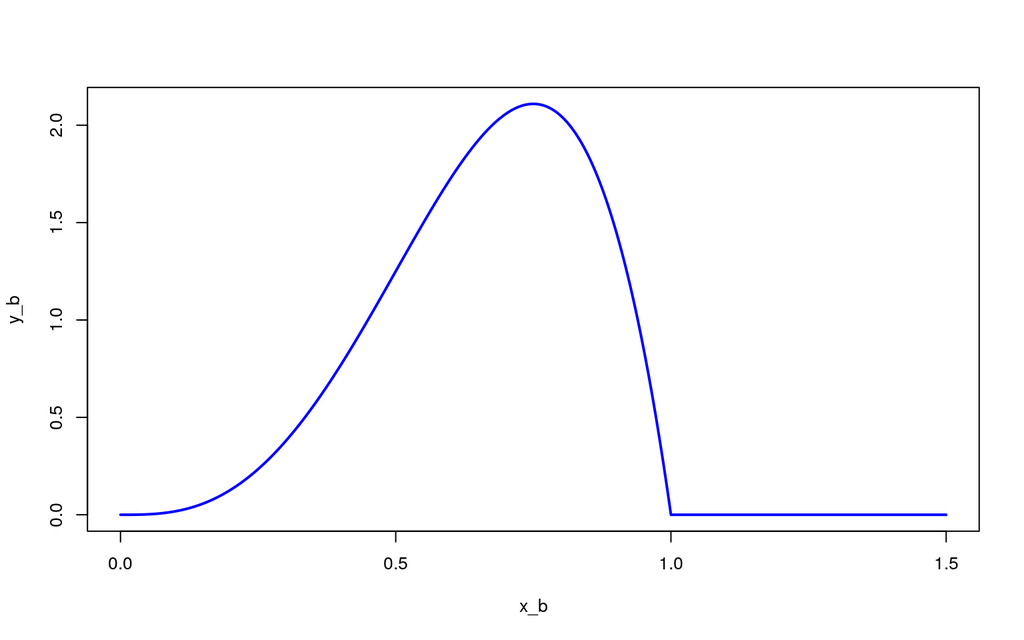

```r
x_b <- seq(0, 1.5, length=1000)
y_b <- dbeta(x_b, 4, 2)
plot(x_b, y_b, type="l", lwd=2, col='blue')
```

Considering the second case, we can immediately cexclude $\pi(\lambda)=Normal(1,2)$ as prior distribution because it refers to the set of real numbers and phone calls length can not be extended to negative values.

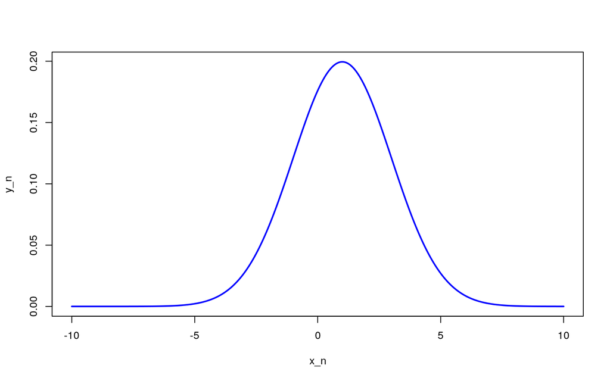

```r
x_n <- seq(-10, 10, length=1000)
y_n <- dnorm(x_n, mean=1, sd=2)
plot(x_n, y_n, type="l", lwd=2, col='blue')
```

We choose the third case as prior distribution: gamma distribution is adequate to describe phone calls.

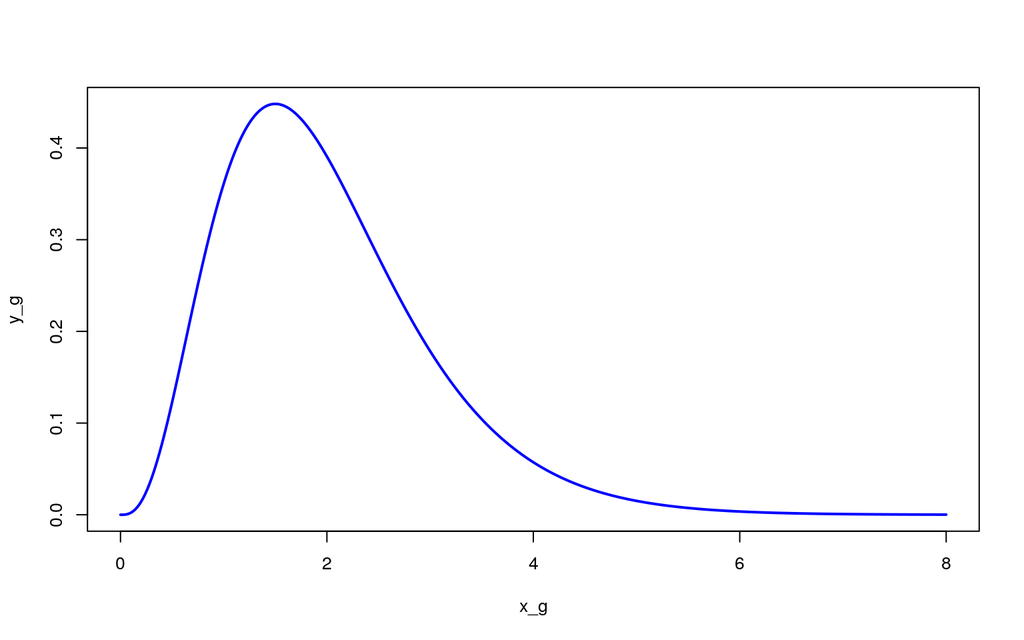

```r
x_g <- seq(0, 8, length=1000)
y_g <- dgamma(x_g, 4, 2)
plot(x_g, y_g, type="l", lwd=2, col='blue')
```

According to our choice, we can compute analitically the posterior distribution. Due to the fact that $y_1,\dots,y_n$ are indpendent, from the definition of Poisson distribution, the likelihood is:
$$L(\lambda;y)= \prod_{i=1}^{n}{\frac{e^{-\lambda}\lambda^{y_i}}{y_i!}}=\frac{e^{-n\lambda}\lambda^{\sum_{i=1}^n{y_i}}}{\prod_{i=1}^{n}{y_i!}}.$$
From the definition of Gamma distribution, the prior is:
$$p(\lambda) = \frac{\beta^\alpha}{\Gamma(\alpha)}\lambda^{\alpha-1}e^{-\beta\lambda}.$$
Then, we can conclude that the posterior is:
$$\pi(\lambda|y) \propto \lambda^{\sum_{i=1}^n{y_i+\alpha-1}}e^{-(n+\beta)\lambda},$$
which is proportional to a Gamma distribution $\mathsf{Gamma}(\sum_{i=1}^n{y_i}+\alpha,n+\beta)$ where $\alpha=4$, $\beta=2$, $n=15$.

### Exercise 8

**Go to this link: [`rstan`](https://github.com/stan-dev/rstan/wiki/RStan-Getting-Started), and follow the instructions to download and install the `rstan` library. Once you did it succesfully, open the file model called `biparametric.stan`, and replace the line:**

`target+=cauchy_lpdf(sigma|0,2.5);`

**with the following one:**

`target+=uniform_lpdf(sigma|0.1,10);`

**Which prior are you now assuming for your parameter $\sigma$? Reproduce the same plots as above and briefly comment.**

#### Solution

The prior distribution for sigma is a Uniform distribution: $p(\sigma) \sim Uniform(0.1,10)$. Therefore our model is:

$$\begin{aligned}
y_1,...,y_n &\sim \mathcal{N}(\theta, \sigma^2)\\
\theta &\sim \text{Unif}(-10,10)\\
\sigma &\sim \text{Unif}(0.1,10)
\end{aligned}$$

```r
## input variables:
# true mean
theta_sample <- 2
# likelihood variance
sigma2 <- 2
# sample size
n <- 10

# generate some data
set.seed(123)
y <- rnorm(n, theta_sample, sqrt(sigma2))
data <- list(N=n, y=y, a=-10, b=10)

# Cauchy prior for the sigma
fit1 <- stan(file="biparametric1.stan", data = data, chains = 4, iter=2000, refresh=-1)
sim1 <- extract(fit1)


# Change the prior: Uniform prior for the sigma
fit2 <- stan(file="biparametric.stan", data = data, chains = 4, iter=2000, refresh=-1)
sim2 <- extract(fit2)
posterior_biv <- as.matrix(fit2)

theta_est <- mean(sim2$theta)
sigma_est <- mean(sim2$sigma)
c(theta_est, sigma_est)
```

```
## [1] 2.092901 1.592337
```

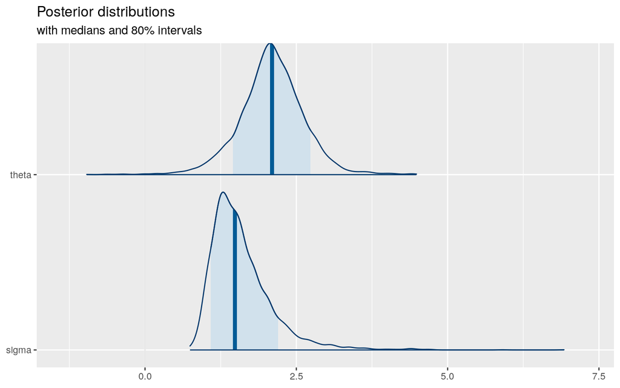

```r
plot_title <- ggtitle("Posterior distributions", "with medians and 80% intervals")

mcmc_areas(posterior_biv, pars = c("theta","sigma"), prob = 0.8, prob_outer=1) +
  plot_title + theme_gray()
```

```r
mcmc_intervals_data(posterior_biv, prob = 0.8, prob_outer=1)
```

```
## # A tibble: 3 x 9
##   parameter outer_width inner_width point_est      ll      l      m      h
##   <fct>           <dbl>       <dbl> <chr>       <dbl>  <dbl>  <dbl>  <dbl>
## 1 theta               1         0.8 median     -0.963   1.45   2.10   2.73
## 2 sigma               1         0.8 median      0.743   1.09   1.49   2.20
## 3 lp__                1         0.8 median    -32.1   -24.5  -22.5  -21.8
## # … with 1 more variable: hh <dbl>
```

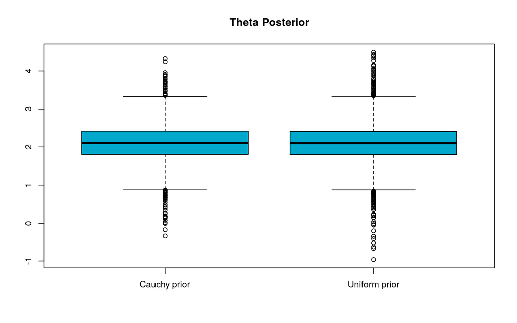

```r
boxplot(sim1$theta, sim2$theta, col = "#00a8cc", main = "Theta Posterior",
        names = c("Cauchy prior", "Uniform prior") )
```

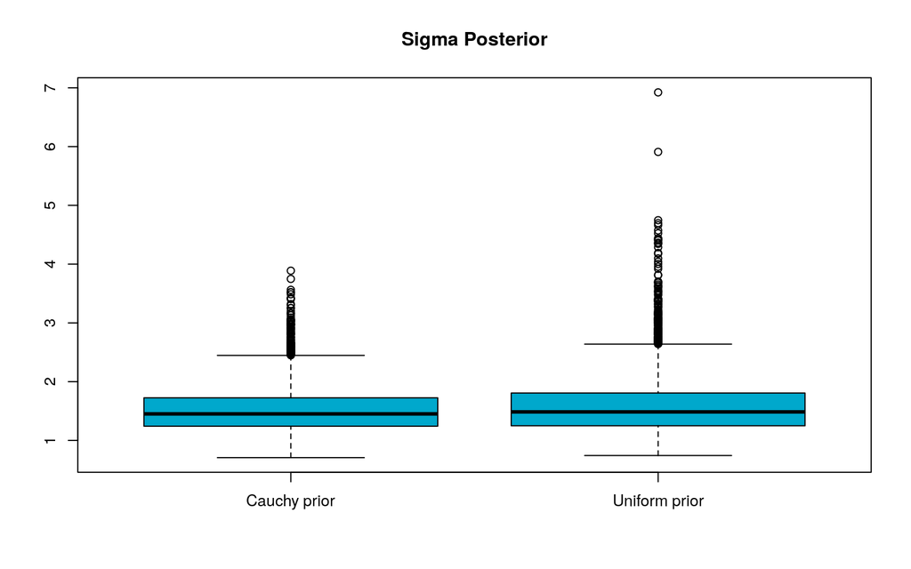

```r
boxplot(sim1$sigma, sim2$sigma, col = "#00a8cc", main = "Sigma Posterior",
        names = c("Cauchy prior", "Uniform prior"))
```

**Conclusion**

[output not shown]

Indeed the resulting plots of the mcmc areas are quite similar to the ones in Lab 3, and also the comparison between the boxplots shows that the posteriors are similar, suggesting that the priors used are not very informative for the posterior, which is more determined by the data.

### Exercise 9

**Reproduce the first plot above for the soccer goals, but this time by replacing Prior 1 with a $Gamma(2,4)$. Then, compute the final Bayes factor matrix (`BF_matrix`) with this new prior and the other ones unchanged, and comment. Is still Prior 2 favorable over all the others?**

#### Solution

We replace the old Prior 1 $Gamma(4.57, 1.43)$ with a $Gamma(2,4)$:

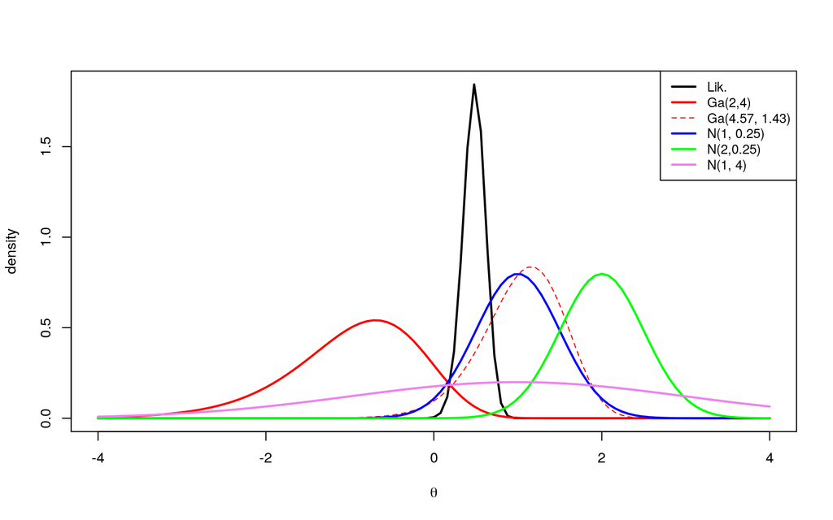

```r
data(soccergoals)

y <- soccergoals$goals

# write the likelihood function via the gamma distribution
lik_pois<- function(data, theta){
  n <- length(data)
  lambda <- exp(theta)
  dgamma(lambda, shape =sum(data)+1, scale=1/n)
}

# write the functions for the prior
prior_gamma <- function(par, theta){
  lambda <- exp(theta)
  dgamma(lambda, par[1], rate=par[2])*lambda
}

prior_norm <- function(npar, theta){
 lambda=exp(theta)
 (dnorm(theta, npar[1], npar[2]))
}

lik_pois_v <- Vectorize(lik_pois, "theta")
prior_gamma_v <- Vectorize(prior_gamma, "theta")
prior_norm_v <- Vectorize(prior_norm, "theta")

## construct the plot for the likelihood function and different priors
# likelihood
curve(lik_pois_v(theta=x, data=y), lwd = 2, xlim=c(-4,4), xlab=expression(theta), ylab = "density")
# prior 1
curve(prior_gamma_v(theta=x, par=c(2, 4)), lwd = 2, col="red", add = TRUE)
# OLD prior 1
curve(prior_gamma_v(theta=x, par=c(4.57, 1.43)), lty = 2, col="red", add = TRUE)
# prior 2
curve(prior_norm_v(theta=x, npar=c(1, .5)), lwd = 2, col="blue", add =TRUE)
# prior 3
curve(prior_norm_v(theta=x, npar=c(2, .5)), lwd = 2, col="green", add =TRUE)
# prior 4
curve(prior_norm_v(theta=x, npar=c(1, 2)), lwd = 2, col="violet", add =TRUE)
legend("topright", c("Lik.", "Ga(2,4)", "Ga(4.57, 1.43)", "N(1, 0.25)", "N(2,0.25)","N(1, 4)"),
       lty=c(1,1,2,1,1,1), lwd=c(2,2,1,2,2,2), col=c("black", "red", "red", "blue", "green",
       "violet"), cex=0.9)
```

We compute the final Bayes factor matrix with this new prior and the other ones unchanged.

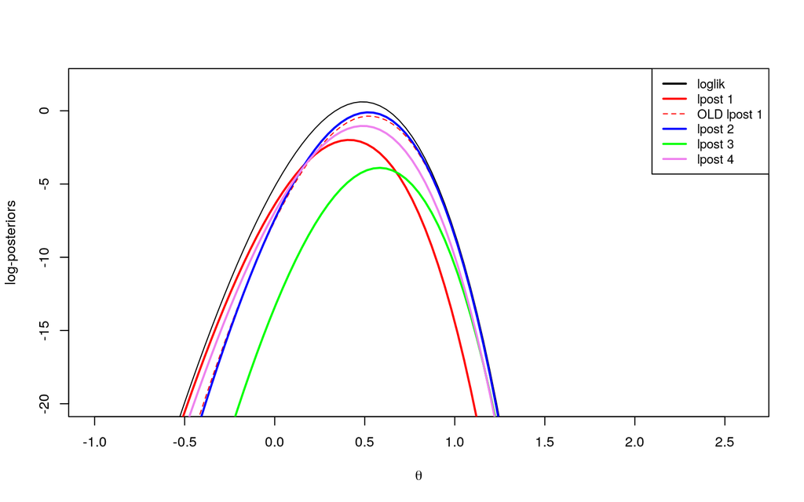

```r
# compute the log posteriors
logpoissongamma <- function(theta, datapar) {
   data <- datapar$data
   par <- datapar$par
   lambda <- exp(theta)
   log_lik <- log(lik_pois(data, theta))
   log_prior <- log(prior_gamma(par, theta))
   return(log_lik+log_prior)
}
logpoissongamma.v <- Vectorize( logpoissongamma, "theta")

logpoissonnormal <- function( theta, datapar) {
 data <- datapar$data
 npar <- datapar$par
 lambda <- exp(theta)
 log_lik <- log(lik_pois(data, theta))
 log_prior <- log(prior_norm(npar, theta))
  return(log_lik+log_prior)
}
logpoissonnormal.v <- Vectorize( logpoissonnormal, "theta")

# log-likelihood
curve(log(lik_pois(y, theta=x)), xlim=c(-1,2.6), ylim=c(-20,2), lwd = 1, ylab="log-posteriors",
      xlab=expression(theta))
# log posterior 1
curve(logpoissongamma.v(theta=x, list(data=y, par=c(2, 4))), col="red", lwd = 2, add =TRUE)
# OLD log posterior 1
curve(logpoissongamma.v(theta=x, list(data=y, par=c(4.57, 1.43))), col="red", lty = 2, add =TRUE)
# log posterior 2
curve(logpoissonnormal.v( theta=x, datapar <- list(data=y, par=c(1, .5))), lwd = 2, col="blue",
      add =TRUE)
# log posterior 3
curve(logpoissonnormal.v( theta=x, datapar <- list(data=y, par=c(2, .5))), lwd = 2, col="green",
      add =TRUE)
# log posterior 4
curve(logpoissonnormal.v( theta=x, list(data=y, par=c(1, 2))), lwd = 2, col="violet",
      add =TRUE)
legend("topright", c( "loglik", "lpost 1", "OLD lpost 1", "lpost 2", "lpost 3", "lpost 4"),
       lty=c(1,1,2,1,1,1), lwd=c(2,2,1,2,2,2), col=c("black", "red", "red", "blue", "green",
       "violet"), cex=0.9)
```

We can see that Prior 2 is still the better one, while our new Prior 1 $Gamma(2, 4)$ (red continuous line) is much worse than the previous one we chose, $Gamma(4.57, 1.43)$ (red dashed line).

Now we compare the models above by using the Bayes Factor, which is the ratio between the marginal likelihood of two models. The larger the BF the better the model in the numerator position.

```r
# compute the log marginal likelihoods using the function laplace()
datapar <- list(data=y, par=c(2, 4))
fit1 <- laplace(logpoissongamma, .5, datapar)
datapar <- list(data=y, par=c(1, .5))
fit2 <- laplace(logpoissonnormal, .5, datapar)
datapar <- list(data=y, par=c(2, .5))
fit3 <- laplace(logpoissonnormal, .5, datapar)
datapar <- list(data=y, par=c(1, 2))
fit4 <- laplace(logpoissonnormal, .5, datapar)

postmode <- c(fit1$mode, fit2$mode, fit3$mode, fit4$mode )
postsds <- sqrt(c(fit1$var, fit2$var, fit3$var, fit4$var))
logmarg <- c(fit1$int, fit2$int, fit3$int, fit4$int)
cbind(postmode, postsds, logmarg)
```

```
##       postmode   postsds   logmarg
## [1,] 0.4139648 0.1301896 -3.108325
## [2,] 0.5207825 0.1260712 -1.255171
## [3,] 0.5825195 0.1224723 -5.076316
## [4,] 0.4899414 0.1320165 -2.137216
```

```r
BF_matrix <- matrix(1, 4,4)
for (i in 1:3){
  for (j in 2:4){
   BF_matrix[i,j]<- exp(logmarg[i]-logmarg[j])
   BF_matrix[j,i]=(1/BF_matrix[i,j])
  }
}

round_bf <- round(BF_matrix,3)
round_bf
```

```
##       [,1]  [,2]   [,3]  [,4]
## [1,] 1.000 0.157  7.156 0.379
## [2,] 6.380 1.000 45.656 2.416
## [3,] 0.140 0.022  1.000 0.053
## [4,] 2.641 0.414 18.899 1.000
```

### Exercise 10

**Let $y=(1, 0, 0, 1, 0, 0, 0, 0, 0, 1, 0, 0, 1, 0)$ collect the results of tossing $n=14$ times an unfair coin, where $1$ denotes heads and $0$ tails, and $p=Prob(y_i=1)$.**

- **Looking at the `Stan` code for the other models, write a short `Stan` Beta-Binomial model, where $p$ has a $Beta(a, b)$ prior with $a=3$, $b=3$.**
- **Extract the posterior distribution with the function `extract()`;**
- **Produce some plots with the `bayesplot` package and comment.**
- **Compute analitically the posterior distribution and compare it with the `Stan` distribution.**

#### Solution

- The `Stan` Beta-Binomial model, contained in the file “beta_binomial.stan”, is:

```r
data{
  int<lower=0> N;
  int s;
  real a;
  real b;
}
parameters{
  real<lower=0,upper=1> p;
}
model{
  target += binomial_lpmf(s | N, p);
  target += beta_lpdf(p | a, b);
}
```

The $\mathsf{R}$ code to use the Stan model is the following:

```r
y <- c(1, 0, 0, 1, 0, 0, 0, 0, 0, 1, 0, 0, 1, 0)
n <- 14

succ <- sum(y)
succ
```

```
## [1] 4
```

```r
#launch Stan model
data <- list(N=n, s=succ, a = 3, b = 3)
fit <- stan(file="beta_binomial.stan", data = data, chains = 4, iter=2000, refresh=-1)
```

- We extract the posterior distribution:

```r
#extract Stan output
sim <- extract(fit)
```

- Some plots are:

```r
p_est <- mean(sim$p)
print(paste("The estamated p is", p_est))
```

```
## [1] "The estamated p is 0.349491136632735"
```

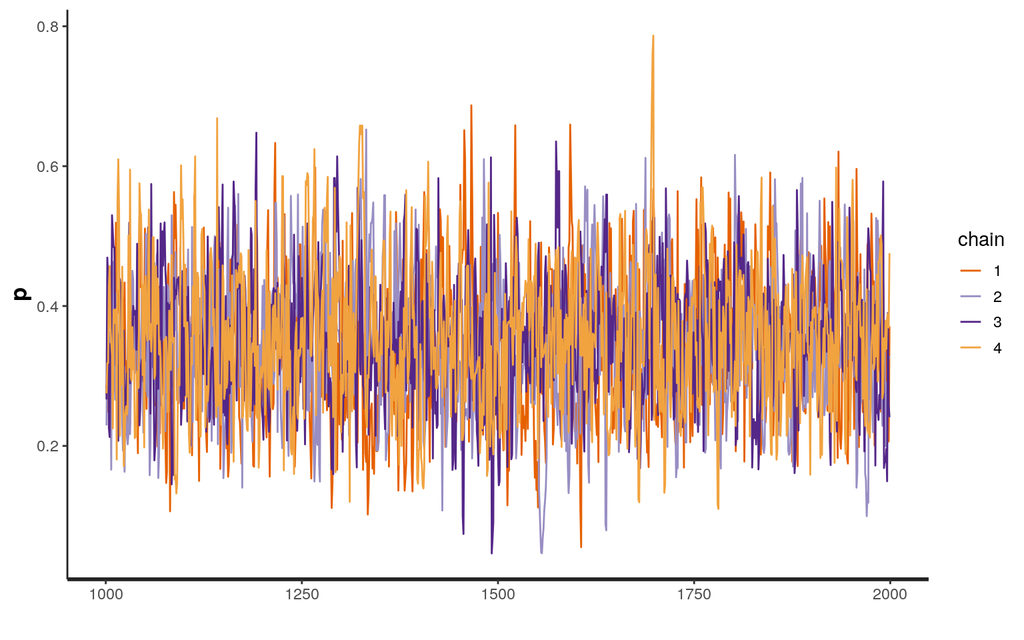

```r
traceplot(fit, pars="p")
```

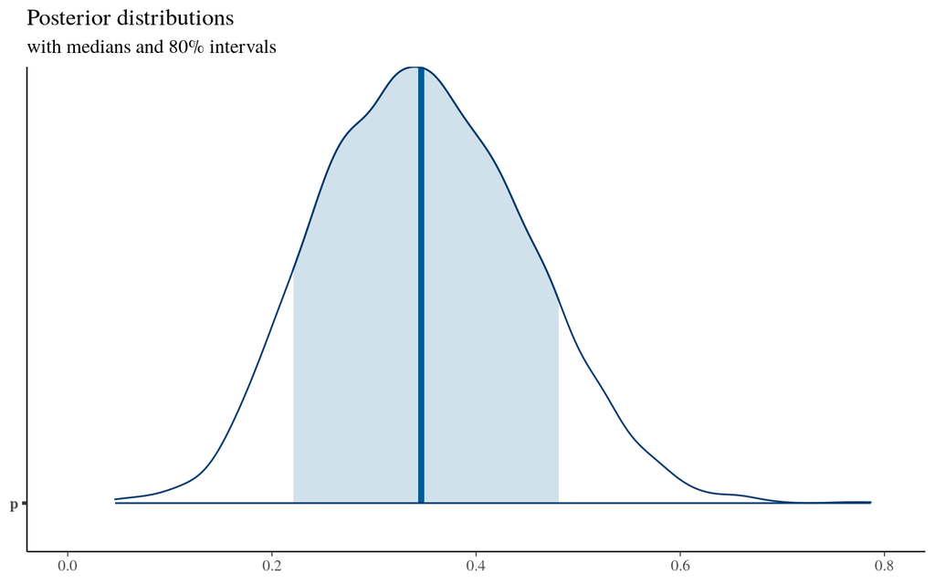

```r
#MCMC areas
posterior <- as.matrix(fit)

plot_title <- ggtitle("Posterior distributions", "with medians and 80% intervals")

mcmc_areas(posterior, pars = "p", prob = 0.8) + plot_title + xlim(0, 0.8)
```

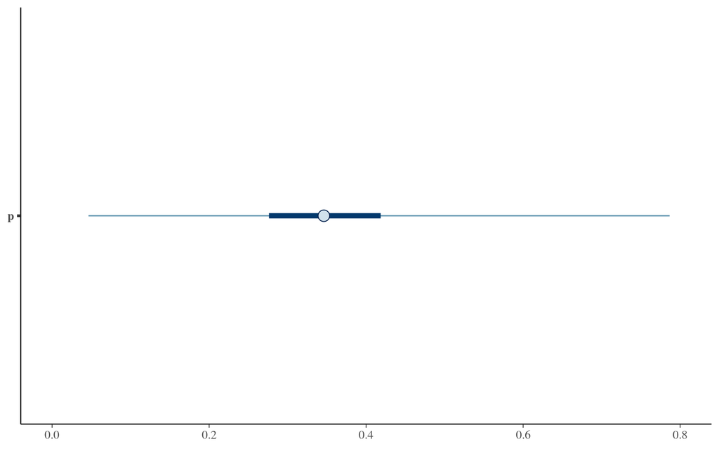

```r
mcmc_intervals(posterior, prob_outer = 1 , pars = "p") + xlim(0, 0.8)
```

- We then perform the analytic computation of the posterior distribution. We have that the prior distribution is
  $$Pr(p) = Beta(\alpha, \beta) = \frac{1}{B(\alpha, \beta)} p^{\alpha-1} (1 - p)^{\beta-1}$$
  while the likelihood is
  $$Pr(\underline{y} \mid p) = \prod_{i=1}^n Bernoulli(p) = \prod_{i=1}^n p^i (1-p)^{1-i} = p^{\sum_{i=1}^n i} (1-p)^{n-\sum_{i=1}^n i}.$$
  The marginal likelihood is instead
  $$\begin{align*}
  Pr(\underline{y}) &= \int_0^1 Pr(\underline{y} \mid p) Pr(p) dp \\
  &= \int_0^1 p^{\sum_{i=1}^n i} (1-p)^{n-\sum_{i=1}^n i} \frac{1}{B(\alpha, \beta)} p^{\alpha-1} (1 - p)^{\beta-1} dp \\
  &=\frac{1}{B(\alpha, \beta)} \int_0^1 p^{\alpha - 1 + \sum_{i=1}^n i} (1-p)^{\beta-1+n -\sum_{i=1}^n i} dp \\
  &= \frac{1}{B(\alpha, \beta)} B \left(\alpha + \sum_{i=1}^n i, \beta + n - \sum_{i=1}^n i \right).
  \end{align*}$$
  So we have that the posterior distibution, for the Bayes theorem, is
  $$\begin{align*}
  Pr(p \mid \underline{y}) &= \frac{Pr(y \mid p) Pr(p)}{Pr(\underline{y})} \\
  &= \frac{p^{\sum_{i=1}^n i} (1-p)^{n-\sum_{i=1}^n i} \frac{1}{B(\alpha, \beta)} p^{\alpha-1} (1 - p)^{\beta-1}}{\frac{1}{B(\alpha, \beta)} B \left(\alpha + \sum_{i=1}^n i, \beta + n - \sum_{i=1}^n i \right)} \\
  &= \frac{1}{ B \left(\alpha + \sum_{i=1}^n i, \beta + n - \sum_{i=1}^n i \right)} p^{\alpha - 1 + \sum_{i=1}^n i} (1-p)^{\beta-1+n -\sum_{i=1}^n i} \\
  &\sim Beta \left(\alpha + \sum_{i=1}^n i, \beta+n -\sum_{i=1}^n i \right).
  \end{align*}$$
  Since $\sum_{i=1}^n i = 4$, $\alpha = 3$ and $\beta=3$ we have that the posterior is a $Beta(7, 13)$.

We compare it with the `Stan` distribution:

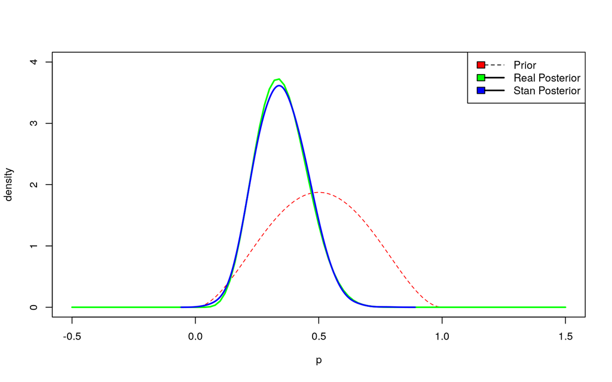

```r
curve(dbeta(x, 3, 3), lty=2, lwd=1, col="red", xlim=c(-0.5, 1.5), ylim=c(0, 4),
      ylab="density", xlab=expression(p))
curve(dbeta(x, 7, 13), col="green", lty=1, lwd=2, add=T)
lines(density(sim$p, adj=2), col ="blue", lty=1, lwd=2)
legend("topright", 1, c("Prior", "Real Posterior", "Stan Posterior"), c("red", "green", "blue"),
       lty=c(2,1,1), lwd=c(1,2,2))
```

We can see that they coincide almost perfectly.